# Problem set2

Shuna

## Problem set 2 - hypothesis testing

For all questions - assume a significance level of = 0.05.

### Question 1

Patients diagnosed with pancreatic cancer are asked about whether they smoke. Patients without pancreatic carcinoma are also asked about if they smoke.

```r
data = matrix(c(80, 40, 40, 50), ncol=2, nrow=2)
colnames(data)= c(" cancer", "no cancer")
row.names(data)= c("smoker", "non smoker")
data
```

```
##             cancer no cancer
## smoker          80        40
## non smoker      40        50
```

1. is having cancer dependent or independent from smoking status?

```r
chisq.test(data)$p.value
```

```
## [1] 0.002074058
```

```
Having p-value of 0.002, we reject the null hypothesis and conclude that there is enough evidence to support that having cancer is dependent on smoking status.
```

2. what is the odds of having cancer given that the patient smokes?

```r
# (80/80+40) / 1- (80/80+40)
80 / 40
```

```
## [1] 2
```

3. what is the odds of having cancer given that the patient does not smoke?

```r
# (40/40+50) / (1 - 40/40+50)
40 / 50
```

```
## [1] 0.8
```

4. what is the odds ratio of this? what does this represent / tell you about the relationship between smoking and cancer.

```r
2.0 / 0.8
```

```
## [1] 2.5
```

```
This means that smokers are 2.5 times more likely to have a cancer.
```

### Question 2

the file ‘telomeres.txt’ contains the estimated telomere lengths estimated from patients normal blood cells and tumour cells. Are telomeres significantly longer in tumours compared to the blood?

```r
telomeres <- read_table("telomeres.txt") |>
  pivot_wider(
    names_from = sample,
    values_from = tel_content
)
```

```
Since each patient has data on control and tumor, and the sample size is failry small, we carry out a paired wilcox test.
```

```r
wilcox.test(
  telomeres$control,
  telomeres$tumor,
  # control is less than tumor
  alternative = "less",
  paired = TRUE
)
```

```
##
##  Wilcoxon signed rank exact test
##
## data:  telomeres$control and telomeres$tumor
## V = 5, p-value = 0.03906
## alternative hypothesis: true location shift is less than 0
```

```
The p-value of 0.03 suggests that telomeres significantly longer in tumours compared to the blood.
```

### Question 3

Is there a significant difference in the median between x and y?

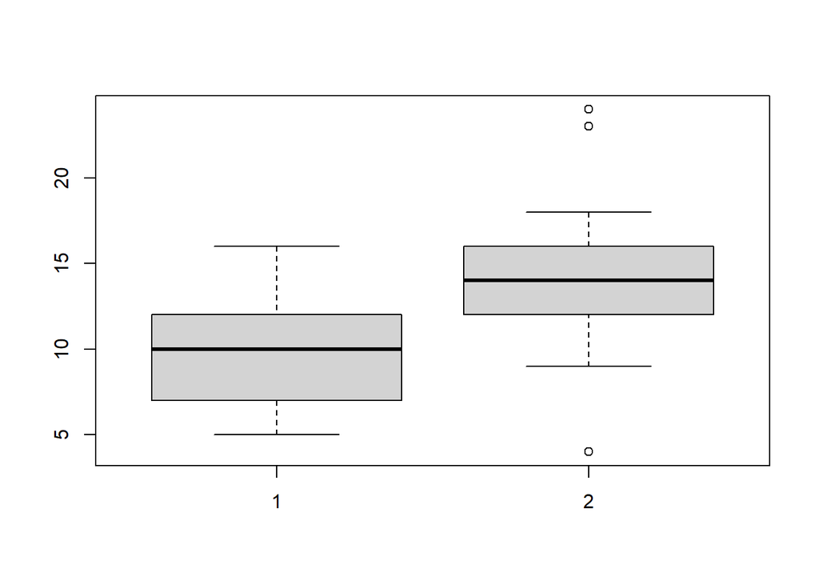

```
Boxplot shows that there seems to be a difference between these two.

As we are looking into difference in median, not mean, we try permutation.
```

```r
x = c( 5,  6,  7,  9, 12, 8, 16, 9, 13, 14, 12, 11, 8, 10, 11, 6, 12,  7, 10, 5, 12, 11, 6, 6, 13)
y = c( 16, 14, 10, 11, 12, 15, 16, 18, 11, 16, 14, 15, 23, 11, 17, 12, 12, 17, 14, 16,9, 18, 14,  4, 24)

boxplot(x,y)
```

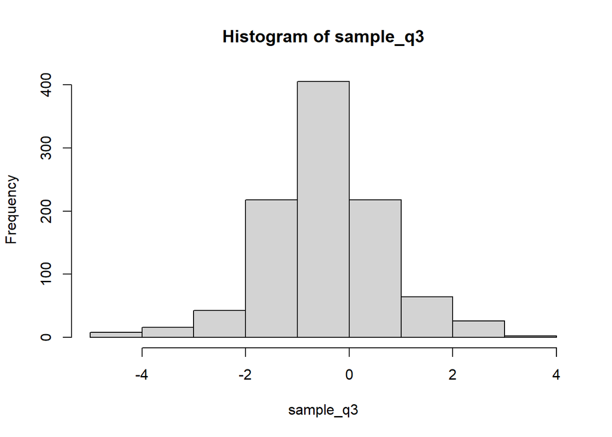

```r
# calculate the test statistic
t_stat <- median(x) - median(y)
# permutation
sample_q3 <- c()
for (i in 1:1000){
  # reorder the total population
  shuffled <- sample(c(x,y))
  # assign first 25 to the x
  sample_x <- shuffled[1:25]
  # assign last 25 to the y
  sample_y <- shuffled[26:50]
  # calculate the statistic
  m <- median(sample_x) - median(sample_y)
  sample_q3 <- c(sample_q3, m)
}

hist(sample_q3)
```

```r
p_value <- sum(t_stat >= sample_q3) / length(sample_q3)
p_value
```

```
## [1] 0.008
```

[output not shown]

### Question 4

The file ‘qpcr.txt’ contains the results from performing qPCR in two conditions on 10 different genes.

Which of the genes are significantly upregulated in treatment compared to control?

```r
qpcr <- read_table2("qpcr.txt")
```

```
 Since each gene has only 6 samples each (control and treatment), the sample size is failry small. As we are just interested in if there is a difference or not, we carry out a wilcox test.
```

```r
genes <- LETTERS[1:10]
p_values <- c()
for (g in genes){
  data <- qpcr |>
    filter(gene == g)
  c <- filter(data, condition == "control")$expression
  t <- filter(data, condition == "treatment")$expression
  # control < treatment
  p <- wilcox.test(c,t, alternative = "less")$p.value
  p_values[g] <- p
}

p_values
```

```
##           A           B           C           D           E           F
## 0.032467532 0.032467532 0.997835498 0.001082251 0.007575758 0.933982684
##           G           H           I           J
## 1.000000000 0.196969697 0.705627706 0.154761905
```

```r
# 0.05 / 10
```

```
 Since we did 10 different hypothesis testing, this will increase the type I error. We can adjust the p-value by dividing by 10 (the number of null hypothesis) and see if the p-value is less than 0.005. Then, only gene D is significant. Alternativly, we can also use `p.adjust()` function to confirm.
```

```r
p.adjust(p_values)
```

```
##          A          B          C          D          E          F          G
## 0.25974026 0.25974026 1.00000000 0.01082251 0.06818182 1.00000000 1.00000000
##          H          I          J
## 0.98484848 1.00000000 0.92857143
```

```
From the results above, we conclude that only gene D is upregulaterd significantly.
```

### Question 5

The file pbc.tsv is a tsv file containing information from Mayo Clinic trial in primary biliary cirrhosis (PBC) of the liver conducted between 1974 and 1984. A total of 424 PBC patients over this interval met eligibility criteria for the randomized placebo controlled trial of the drug D-penicillamine

| var | description |
| --- | --- |
| age | in years |
| albumin | serum albumin (g/dl) |
| alk.phos | alkaline phosphotase (U/liter) |
| ascites | presence of ascites |
| ast | aspartate aminotransferase, once called SGOT (U/ml) |
| bili | serum bilirunbin (mg/dl) |
| chol | serum cholesterol (mg/dl) |
| copper | urine copper (ug/day) |
| edema | 0 no edema, 0.5 untreated or successfully treated, 1 edema despite diuretic therapy |
| hepato | presence of hepatomegaly or enlarged liver |
| id | case number |
| platelet | platelet count |
| protime | standardised blood clotting time |
| sex | m/f |
| spiders | blood vessel malformations in the skin |
| stage | histologic stage of disease (needs biopsy) |
| status | status at endpoint, 0/1/2 for censored, transplant, dead |
| time | number of days between registration and the earlier of death, transplantion, or study analysis in July, 1986 |
| trt | 1/2/NA for D-penicillmain, placebo, not randomised |
| trig | triglycerides (mg/dl) |

```r
pbc <- read_table("E:/Academics/Stats/Problem Set 2/pbc.tsv")
head(pbc)
```

```
## # A tibble: 6 x 20
##      id  time status   trt   age sex   ascites hepato spiders edema  bili  chol
##   <dbl> <dbl>  <dbl> <dbl> <dbl> <chr>   <dbl>  <dbl>   <dbl> <dbl> <dbl> <dbl>
## 1     1   400      2     1  58.8 f           1      1       1   1    14.5   261
## 2     2  4500      0     1  56.4 f           0      1       1   0     1.1   302
## 3     3  1012      2     1  70.1 m           0      0       0   0.5   1.4   176
## 4     4  1925      2     1  54.7 f           0      1       1   0.5   1.8   244
## 5     5  1504      1     2  38.1 f           0      1       1   0     3.4   279
## 6     6  2503      2     2  66.3 f           0      1       0   0     0.8   248
## # ... with 8 more variables: albumin <dbl>, copper <dbl>, alk.phos <dbl>,
## #   ast <dbl>, trig <dbl>, platelet <dbl>, protime <dbl>, stage <dbl>
```

1. Is there a significant difference in age between patients who are on D-penicillmain or are on placebo?

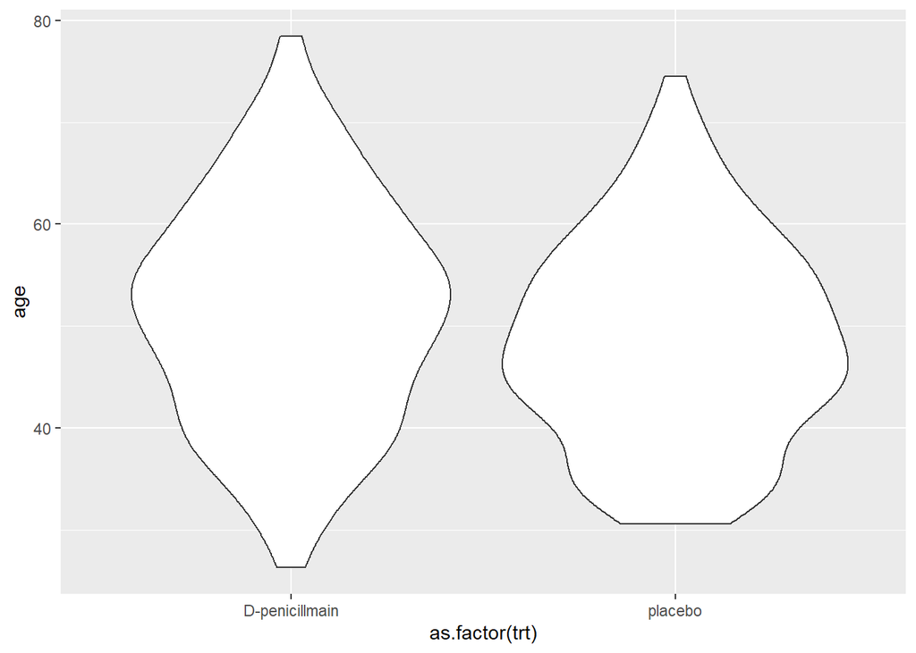

```r
pbc_a <- pbc |>
  filter(!(is.na(trt) | is.na(age)))|>
  select(age, trt)
pbc_a |>
  ggplot(aes(as.factor(trt), age)) +
  geom_violin() +
  scale_x_discrete(label = c("D-penicillmain", "placebo"))
```

```r
D <- filter(pbc_a, trt == 1)$age
P <- filter(pbc_a, trt == 2)$age
```

```
The plot does not show any obvious difference. And the data looks okay-ly normally distributed. We can do a t-test.
```

```r
var.test(D,P)
```

```
##
##  F test to compare two variances
##
## data:  D and P
## F = 1.2219, num df = 157, denom df = 153, p-value = 0.2139
## alternative hypothesis: true ratio of variances is not equal to 1
## 95 percent confidence interval:
##  0.8904774 1.6754640
## sample estimates:
## ratio of variances
##           1.221858
```

```r
# no support that the variances are equal
```

```r
t.test(D,P, var.equal = FALSE)$p.value
```

```
## [1] 0.01753178
```

```
There is a significant difference in age between patients who are on D-penicillmain and are on placebo.
```

2. Is being treated with D-penicillamine dependent or independent from sex?

```r
pbc_b <- pbc |>
  filter(!is.na(trt)) |>
  select(sex, trt) |>
  mutate(trt = as.character(trt)) |>
  group_by(sex, trt) |>
  summarise(dp = n()) |>
  ungroup() |>
  pivot_wider(names_from = trt, values_from = dp) |>
  as.data.frame()

chisq.test(pbc_b[-1])
```

```
##
##  Pearson's Chi-squared test with Yates' continuity correction
##
## data:  pbc_b[-1]
## X-squared = 0.64689, df = 1, p-value = 0.4212
```

```
From the result, we conclude that being treated with D-pencillamine is independent from sex.
```

3. Is having spiders independent from disease stage?

```r
pbc_c <- pbc |>
  select(spiders, stage) |>
  filter(!(is.na(spiders) | is.na(stage))) |>
  group_by(stage, spiders) |>
  summarise(sp = n()) |>
  pivot_wider(names_from = spiders, values_from = sp) |>
  as.data.frame() |>
  print()
```

```
##   stage  0  1
## 1     1 15  1
## 2     2 58  9
## 3     3 90 30
## 4     4 59 50
```

```r
chisq.test(pbc_c[-1], simulate.p.value = TRUE)
```

```
##
##  Pearson's Chi-squared test with simulated p-value (based on 2000
##  replicates)
##
## data:  pbc_c[-1]
## X-squared = 27.993, df = NA, p-value = 0.0004998
```

```
As one of the values in the dataframe is quite small, chi-squared test may yield an inaccurate result. To avoid that, we set simulate.p.value = TRUE which computes p-values by Monte Carlo simulation. From the result, we conclude that having spiders is dependent on disease stage.
```

4. Is there a significant different in cholesterol levels between people with or without an enlarged liver (hepatomegaly)?

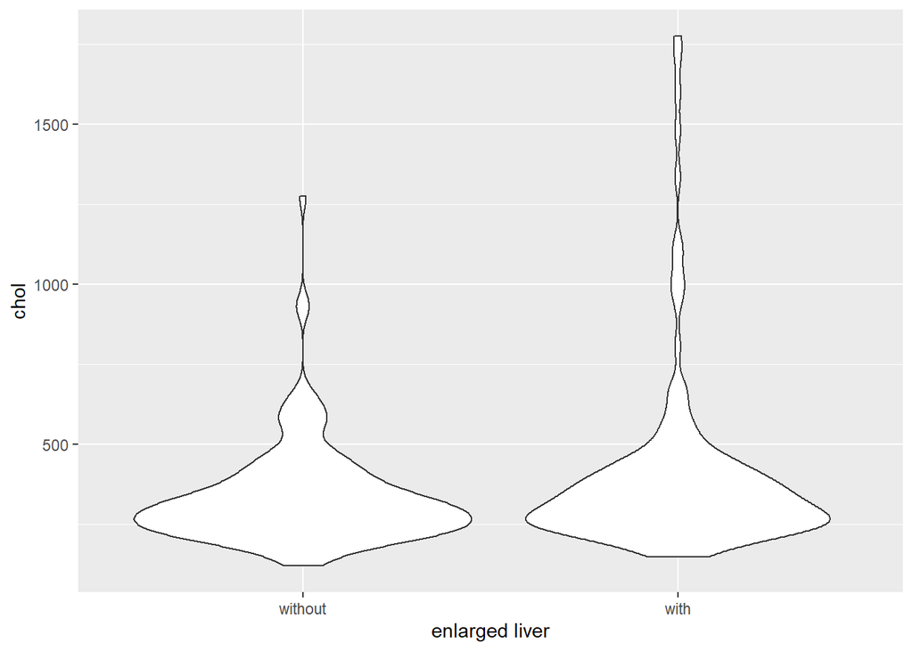

```
Well the data does not seem normally distributed, and as we are not so concerned with the difference in mean, we should consider wilcox test.
```

```r
pbc_d <- pbc |>
  select(hepato, chol) |>
  filter(!(is.na(hepato) | is.na(chol)))


pbc_d |>
  ggplot(aes(as.character(hepato), chol))+
  geom_violin() +
  scale_x_discrete(label = c("without", "with")) +
  labs(x = "enlarged liver")
```

```r
wo <- filter(pbc_d, hepato == 0)$chol
w <- filter(pbc_d, hepato == 1)$chol
wilcox.test(wo,w)
```

```
##
##  Wilcoxon rank sum test with continuity correction
##
## data:  wo and w
## W = 8852.5, p-value = 0.07858
## alternative hypothesis: true location shift is not equal to 0
```

[output not shown]

### Question 6

A woman claims to be able to tell if tea is prepared with milk added to the cup first or added after the tea was poured.

She tastes 20 cups of tea (10 with the milk poured in first and 10 with the milk poured in after) …. and correctly guesses that the milk has been poured first 8 times and that the milk has been poured in last 6 times.

What is the null and alternative hypothesis for this experiment?

```
The null hypothesis: Her result is out of random choice and there is no relationship between her choice and actual order.
The alternative hypothesis: She can correctly identify which is poured first.
```

Can she justify her claim to be able to do this ?

```
No she cannot. We have set our signifncance level \alpha to be 0.05 for this problem set. Under this restraint, her trial of 20 times should yield at most one error to call it significant. Since she wrong-guessed 6 times, we fail to reject the null hypothesis.
```

### Question 7

1. What is the relationship between power and type II errors?

   Power equals to 1 minus the probability of having type II errors. Power is the ability of a test to correctly reject false negatives. Type II errors are false negatives, i.e., when the alternative hypothesis is true but we fail to reject the null hypothesis.
2. How many replicates do I need to perform to achieve 80% power to detect a change in the mean between two conditions of 2? (assume the data is normally distributed so t-tests apply). I ran a pilot experiment and collected the following data.

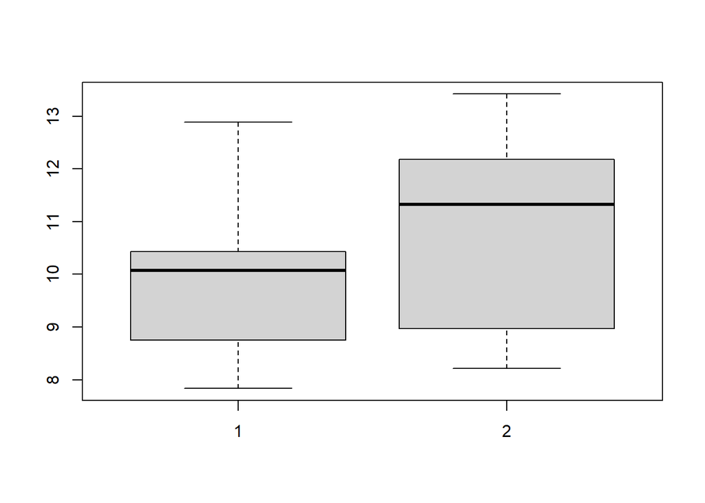

```r
treatment = c( 7.835008, 12.887306, 10.427879,  8.749182, 10.075484)
control = c(12.182948,  8.972897,  8.215060, 13.421730, 11.325449)
boxplot(treatment, control)
```

```r
t_sd <- sd(treatment)
c_sd <- sd(control)
```

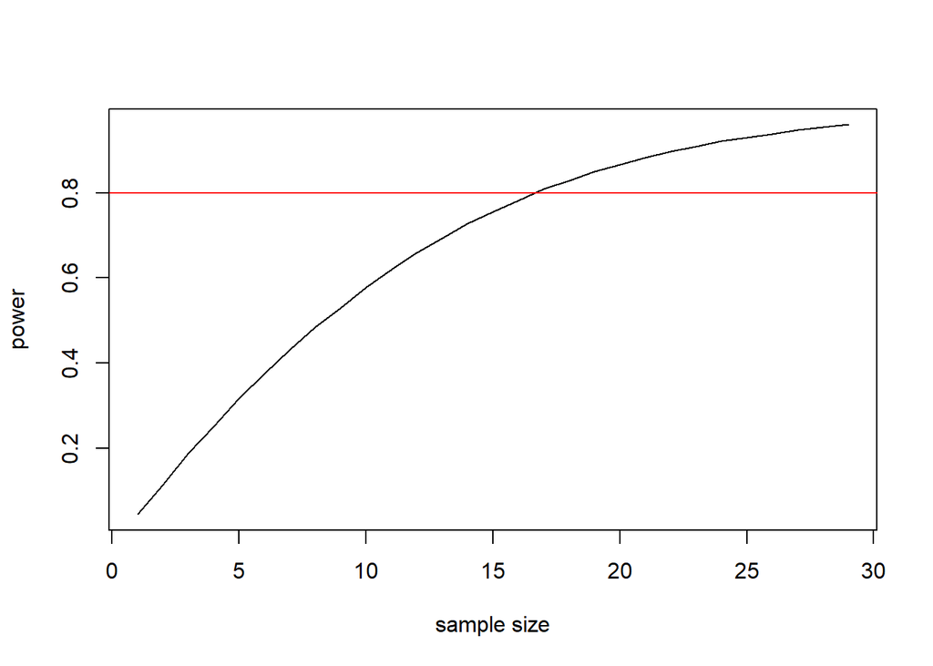

```r
# prepare an empty vector for storing power
power <- c()
# check the sample size from 2 to 30
for(i in 2:30){
  # prepare an empty vector for replication
  power_rep <- c()
  # replicate for 100 times
  for (j in 1:100){
    # prepare an empty vector to store simulation
    result <- c()
    # simulation
    for (k in 1:1000){
      # two samples, different standard deviation
      # difference in mean of 2
      x <- rnorm(i, 2, t_sd)
      y <- rnorm(i, 0, c_sd)
      # p-value
      result = c(result, t.test(x, y, var.equal = FALSE)$p.value)
    }
    # calculate false negatives
    z <- 1 - sum(result > 0.05) / length(result)
    # store power
    power_rep <- c(power_rep, z)
  }
  # calculate the mean of power
  m_power_rep <- mean(power_rep)
  # append
  power <- c(power, m_power_rep)
}

# plot
plot(power, type = "lm", xlab = "sample size")
abline(h = 0.8, col = "red")
```

```r
power
```

```
##  [1] 0.04469 0.11378 0.18806 0.25213 0.31770 0.37642 0.43171 0.48446 0.52903
## [10] 0.57739 0.62070 0.65991 0.69303 0.72762 0.75544 0.78161 0.80854 0.82793
## [19] 0.84963 0.86669 0.88183 0.89677 0.90913 0.92068 0.92958 0.93717 0.94720
## [28] 0.95355 0.95982
```

[output not shown]